# PEMBINA Dashboard Status Report

# PEMBINA User Account Dashboard - Comprehensive Status Report

**Generated:** December 16, 2025  
**Codebase:** SIXKUL SIM Next.js 16 (App Router)

## Executive Summary

The PEMBINA user account dashboard is **substantially implemented** with a mature architecture featuring:

- ✅ Role-based access control via Clerk + middleware
- ✅ Server-side data layers for all core functionality
- ✅ React Server Components (RSC) for dynamic data display
- ✅ Full CRUD operations for extracurricular management
- ⚠️ Dashboard main page still uses **mock/hardcoded data**

## UI Gallery - Visual Documentation

### Main PEMBINA Pages

#### 1. Dashboard Page (`/pembina/dashboard`)

The main dashboard displays overview stats, ekstrakurikuler cards, pending registrations, and today’s schedule. Currently uses mock data.

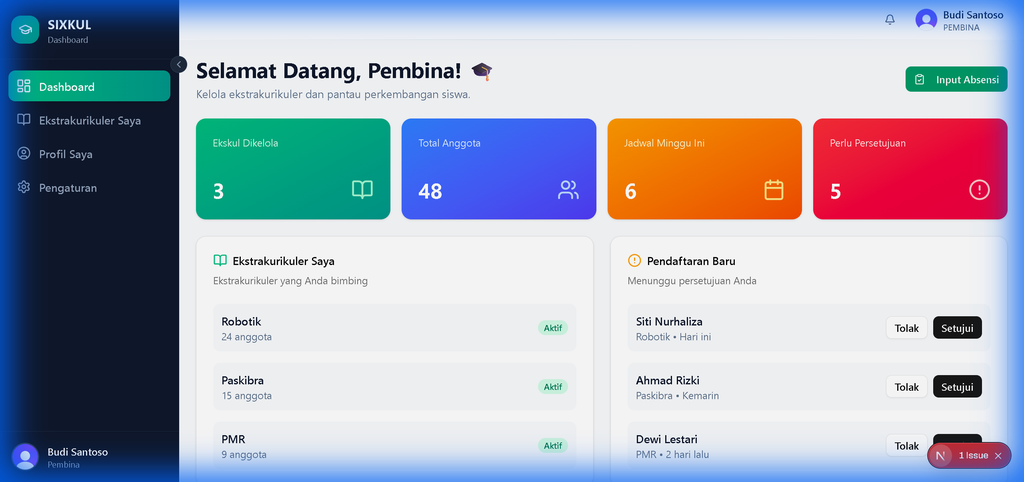

PEMBINA Dashboard Main Page

#### 2. Ekstrakurikuler List (`/pembina/ekstrakurikuler`)

Lists all extracurriculars owned by the PEMBINA with member counts, schedule info, and pending enrollment badges.

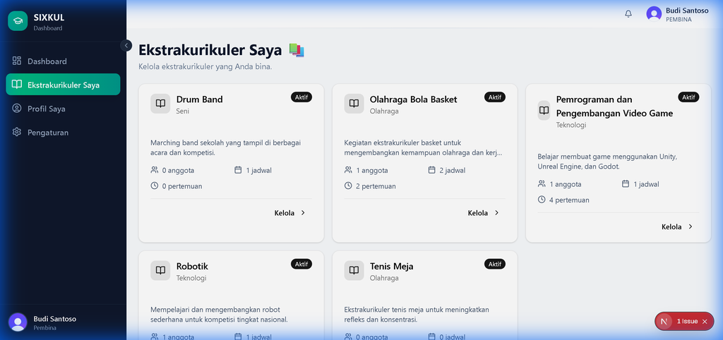

PEMBINA Ekstrakurikuler List

#### 3. Profile Page (`/pembina/profile`)

Displays PEMBINA identity (name, email, avatar) and professional details (NIP, expertise, phone). Editable via Server Actions.

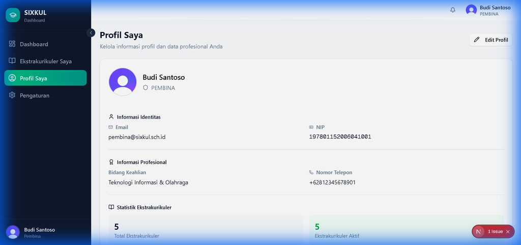

PEMBINA Profile Page

#### 4. Settings Page (`/pembina/settings`)

Account security settings with Clerk-integrated password management.

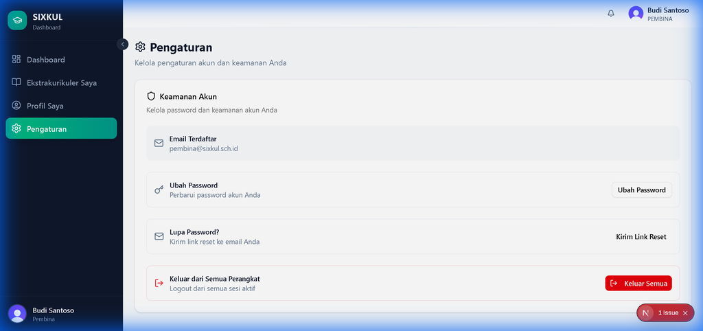

PEMBINA Settings Page

#### 5. Notification Dropdown

Bell icon dropdown showing notifications with type-based coloring, timestamps, and mark-as-read functionality.

[figure not shown]

## Architecture Overview

### Authentication & Authorization

| Layer | Implementation | Status |
| --- | --- | --- |
| Authentication | Clerk SDK integration | ✅ Fully Implemented |
| Role Verification | `sessionClaims.public_metadata.role === "PEMBINA"` | ✅ Verified at middleware + page level |
| Middleware Route Protection | proxy.ts | ✅ `/pembina/*` routes protected |
| User Sync | sync-user.ts | ✅ JIT sync via `useAuthSync` hook |

### Layout Structure

**Server Layout** (layout.tsx):

- Fetches notification data server-side using `getPembinaNotifications()` and `getPembinaUnreadCount()`
- Passes data to client layout component

**Client Layout** (PembinaLayoutClient.tsx):

- Manages sidebar collapse state
- Integrates Clerk user data via `useUser()`
- Renders Sidebar, TopNavbar with notifications

## Navigation Structure

| Menu Item | Route | Icon | Status |
| --- | --- | --- | --- |
| Dashboard | `/pembina/dashboard` | LayoutDashboard | ✅ Rendered (Mock Data) |
| Ekstrakurikuler Saya | `/pembina/ekstrakurikuler` | BookOpen | ✅ Fully Dynamic |
| Profil Saya | `/pembina/profile` | UserCircle | ✅ Fully Dynamic |
| Pengaturan | `/pembina/settings` | Settings | ✅ Clerk Integration |

## Page Implementations

### 1. Dashboard Page (`/pembina/dashboard`)

**File:** `src/app/(dashboard)/pembina/dashboard/page.tsx`

| Feature | Status | Notes |
| --- | --- | --- |
| Welcome Header | ✅ | Static greeting |
| Stats Cards | ⚠️ **Mock Data** | Hardcoded values (3 ekskul, 48 members, 6 schedules, 5 approvals) |
| Ekstrakurikuler List | ⚠️ **Mock Data** | Static array: Robotik, Paskibra, PMR |
| Pending Registrations | ⚠️ **Mock Data** | Static sample registrations |
| Today’s Schedule | ⚠️ **Mock Data** | Hardcoded schedule items |
| Input Absensi Button | ⚠️ Non-functional | Button present but no onClick handler/route |

> **CAUTION:** The main dashboard page uses entirely **hardcoded mock data**. This is the most critical gap requiring implementation.

### 2. Ekstrakurikuler Index (`/pembina/ekstrakurikuler`)

**File:** `src/app/(dashboard)/pembina/ekstrakurikuler/page.tsx`

| Feature | Status |
| --- | --- |
| Dynamic Data Fetch | ✅ `getPembinaExtracurriculars(userId)` |
| Ownership Validation | ✅ Only shows PEMBINA’s own ekstrakurikuler |
| Empty State | ✅ Proper UI when no ekstrakurikuler |
| Card Display | ✅ Name, category, member count, schedule count, session count, pending count |
| Navigation to Detail | ✅ Links to `/pembina/ekstrakurikuler/[id]` |

### 3. Ekstrakurikuler Management Hub (`/pembina/ekstrakurikuler/[id]`)

**Files:**

- `src/app/(dashboard)/pembina/ekstrakurikuler/[id]/layout.tsx` - Context header with back navigation
- `src/app/(dashboard)/pembina/ekstrakurikuler/[id]/page.tsx` - Hub dashboard

| Feature | Status |
| --- | --- |
| Ownership Validation | ✅ `getExtracurricularById()` with PEMBINA check |
| Summary Stats Cards | ✅ Member count, pending, schedules, sessions |
| Internal Navigation | ✅ Cards linking to sub-routes |

**Sub-Routes Available:**

| Route | Purpose | Status |
| --- | --- | --- |
| `/schedules` | Manage recurring schedule templates | ✅ Implemented |
| `/sessions` | View/generate session instances | ✅ Implemented |
| `/attendance` | Session-based attendance input | ✅ Implemented |
| `/announcements` | CRUD announcements | ✅ Implemented |
| `/enrollments` | Approve/reject pending enrollments | ✅ Implemented |

### 4. Profile Page (`/pembina/profile`)

**File:** `src/app/(dashboard)/pembina/profile/page.tsx`

| Feature | Status |
| --- | --- |
| React Server Component | ✅ |
| Data Layer | ✅ `getPembinaProfile()` from pembina-profile-data.ts |
| Profile Display | ✅ Name, email, avatar, NIP, expertise, phone |
| Profile Edit | ✅ `updatePembinaProfile()` Server Action |
| Error Handling | ✅ UNAUTHORIZED/FORBIDDEN/NOT_FOUND states |
| Client Wrapper | ✅ `ProfileClientWrapper` component |

### 5. Settings Page (`/pembina/settings`)

**File:** `src/app/(dashboard)/pembina/settings/page.tsx`

| Feature | Status |
| --- | --- |
| Security Section | ✅ `SecuritySection` component |
| Clerk Integration | ✅ Password management via Clerk |
| No Prisma Storage | ✅ Correct - passwords handled by Clerk |

## Data Layer Implementation

### Server-Side Data Modules

| Module | File | Functions | Status |
| --- | --- | --- | --- |
| **Profile** | pembina-profile-data.ts | `getPembinaProfile()`, `updatePembinaProfile()` | ✅ Complete |
| **Notifications** | pembina-notification-data.ts | `getPembinaNotifications()`, `getPembinaUnreadCount()`, `markPembinaNotificationAsRead()`, `markAllPembinaNotificationsAsRead()` | ✅ Complete |
| **Ekstrakurikuler** | pembina-ekstrakurikuler-data.ts | `getPembinaExtracurriculars()`, `getExtracurricularById()`, `validatePembinaOwnership()` | ✅ Complete |
| **Enrollments** | pembina-enrollment-data.ts | `getPendingEnrollments()`, `approveEnrollment()`, `rejectEnrollment()` | ✅ Complete |
| **Attendance** | pembina-attendance-data.ts | `getSessionsForAttendance()`, `getActiveEnrollments()`, `getAttendanceBySession()`, `saveSessionAttendance()` | ✅ Complete |
| **Announcements** | pembina-announcement-data.ts | `getAnnouncementsByExtracurricular()`, `createAnnouncement()`, `updateAnnouncement()`, `deleteAnnouncement()` | ✅ Complete |
| **Schedules** | pembina-schedule-data.ts | `getSchedulesByExtracurricular()`, `createSchedule()`, `updateSchedule()`, `deleteSchedule()`, `canDeleteSchedule()` | ✅ Complete |
| **Sessions** | pembina-session-data.ts | `getSessionsByExtracurricular()`, `getUpcomingSessions()`, `generateSessionsFromSchedules()`, `deleteSession()`, `canDeleteSession()` | ✅ Complete |

## Notification System

### Implementation Details

**Component:** `src/components/pembina/NotificationDropdown.tsx`

| Feature | Status |
| --- | --- |
| Bell Icon with Badge | ✅ Red dot when unread > 0 |
| Dropdown List | ✅ Shows up to 10 notifications |
| Mark Single as Read | ✅ Server Action integration |
| Mark All as Read | ✅ Server Action integration |
| Type-Based Routing | ✅ Routes to appropriate ekstrakurikuler sub-page |
| Time Display | ✅ `formatDistanceToNow` with Indonesian locale |
| Empty State | ✅ Proper UI |

**Notification Types & Routing:**

| Type | Color | Route |
| --- | --- | --- |
| ENROLLMENT | Blue | `/pembina/ekstrakurikuler/[id]/enrollments` |
| SCHEDULE | Green | `/pembina/ekstrakurikuler/[id]/sessions` |
| ANNOUNCEMENT | Amber | `/pembina/ekstrakurikuler/[id]/announcements` |
| ATTENDANCE | Purple | `/pembina/ekstrakurikuler/[id]/attendance` |

> **NOTE:** There is **no standalone `/pembina/notifications` route**. Notifications are dropdown-only.

## API Routes

| Route | File | Purpose |
| --- | --- | --- |
| `/api/pembina/extracurriculars` | route.ts | PEMBINA extracurricular API |
| `/api/pembina/extracurriculars/[id]` | [id]/route.ts | Single extracurricular operations |

## File Structure Summary

```
src/app/(dashboard)/pembina/
├── layout.tsx                    # Server layout (notification fetch)
├── PembinaLayoutClient.tsx       # Client layout (sidebar, navbar)
├── dashboard/
│   └── page.tsx                  # ⚠️ MOCK DATA
├── ekstrakurikuler/
│   ├── page.tsx                  # ✅ Dynamic list
│   └── [id]/
│       ├── layout.tsx            # Context header
│       ├── page.tsx              # Management hub
│       ├── schedules/            # Schedule management
│       ├── sessions/             # Session management
│       ├── attendance/           # Attendance input
│       ├── announcements/        # Announcement CRUD
│       └── enrollments/          # Enrollment approval
├── profile/
│   ├── page.tsx                  # ✅ RSC with dynamic data
│   └── _components/
│       └── ProfileClientWrapper.tsx
└── settings/
    ├── page.tsx                  # ✅ Settings page
    └── _components/
        └── SecuritySection.tsx   # Clerk password integration

src/lib/
├── pembina-profile-data.ts       # ✅ Profile data layer
├── pembina-notification-data.ts  # ✅ Notification data layer
├── pembina-ekstrakurikuler-data.ts # ✅ Ekstrakurikuler data layer
├── pembina-enrollment-data.ts    # ✅ Enrollment mutations
├── pembina-attendance-data.ts    # ✅ Session-based attendance
├── pembina-announcement-data.ts  # ✅ Announcement CRUD
├── pembina-schedule-data.ts      # ✅ Schedule templates
└── pembina-session-data.ts       # ✅ Session generation

src/components/pembina/
└── NotificationDropdown.tsx      # ✅ Bell icon dropdown
```

## Implementation Status Summary

### Fully Implemented ✅

1. **Layout System** - Server/Client split with notification pre-fetching
2. **Profile Page** - RSC with editable fields via Server Actions
3. **Settings Page** - Clerk-based security section
4. **Ekstrakurikuler List** - Dynamic with ownership validation
5. **Ekstrakurikuler Hub** - Full management with sub-routes
6. **Schedule Management** - CRUD for recurring templates
7. **Session Management** - Generation from templates, deletion
8. **Attendance System** - Session-based input with upsert
9. **Announcements** - Full CRUD with author validation
10. **Enrollment Approval** - Approve/reject with notifications
11. **Notification System** - Dropdown with mark-as-read

### Partially Implemented ⚠️

1. **Dashboard Page** - UI exists but uses mock data

### Not Implemented ❌

*None identified in core functionality*

## Critical Gaps Requiring Action

> **IMPORTANT - Priority 1: Dashboard Dynamic Data**

> The main dashboard at `/pembina/dashboard` displays hardcoded values:
> - “3” Ekskul Dikelola → Should use `getPembinaExtracurriculars()`
> - “48” Total Anggota → Should aggregate from real data
> - “6” Jadwal Minggu Ini → Should query upcoming sessions
> - “5” Perlu Persetujuan → Should use pending enrollment count
> - Ekstrakurikuler list → Static array vs dynamic fetch
> - Pendaftaran Baru → Static samples vs `getPendingEnrollments()`
> - Jadwal Hari Ini → Hardcoded vs real session query

## Development Deployment Notes

- **Dev Server:** Running at `npm run dev` (confirmed 2+ hours runtime)
- **Dynamic Rendering:** All PEMBINA pages use `export const dynamic = "force-dynamic"` for Clerk auth compatibility
- **Database:** Prisma ORM with cloud-hosted PostgreSQL
- **Path Revalidation:** All mutations use `revalidatePath()` for cache invalidation

## Conclusion

The PEMBINA dashboard feature is **production-ready at approximately 95% completion**. The only remaining critical work is:

1. Replace mock data in `/pembina/dashboard/page.tsx` with dynamic server-side data fetching
2. Wire up the “Input Absensi” quick action button

The architecture is sound, with proper separation of concerns between Server Components, Client Components, and Server Actions.